# KSPZV1 DGE Δ (postvax/baseline) limma voom - revision

Tuan M. Tran

05/13/2021

### Objective

Perform differential gene expression using limma voom to assess differences between protected and not protected infants in the KSPZV1 malaria vaccine trial. This analysis specifically evaluates differences in post-vax with adjustment for baseline.

This analysis also includes adjustments for:

1. Batch
2. Sex
3. Study site
4. log10(CSP Ab + 1)
5. number of malaria infections during vaccination period

### Load required packages

```r
library(knitr)
library(tidyverse)
library(limma)
library(edgeR)
library(googledrive)
library(tidyverse)
library(fgsea)
library(data.table)
library(EDASeq)
library(gtools)
```

### Load ExpressionSet

```r
#from google drive
#local path
#/Volumes/GoogleDrive/My Drive/Tran Lab Shared/Projects/Doris Duke PfSPZ Kenya/Tuan PfSPZ/KenyaPfSPZ/Final Data Files/KSPZV1 SeqExpressionSet Baseline Postvax Reduced Phenodat 35716x487.rds

temp <- tempfile(fileext = ".rds")
dl <- drive_download(
  as_id("17P7RwDaPCwDXcrD82N4fYd3vGOcueFEH"), path = temp, overwrite = TRUE)
x <- readRDS(file = dl$local_path)
x$treat <- factor(x$treat, levels = c("Placebo", "4.5 x 10^5 PfSPZ", "9.0 x 10^5 PfSPZ", "1.8 x 10^6 PfSPZ"))
```

### Set options

```r
myGroups <- unique(x$treat)
```

[output not shown]

### Reduce to high dose (1.8 x 10^6 PfSPZ) only

This reduces the time and enables the code to be knitted without throwing errors related to url connections. Can leave out if all treatment groups are analyzed when script is ran locally.

```r
myList <- c("1.8 x 10^6 PfSPZ")
for (name in myList) {
  xgroup <- xgroup[name]
}
```

### Build DGEList Object

```r
#Define group by dose, timepoint and outcome
ygroup <- xgroup
for(i in names(ygroup)){
  ygroup[[i]]  <- DGEList(counts=counts(xgroup[[i]]), genes=fData(xgroup[[i]]), group= factor(paste(xgroup[[i]]$treat, xgroup[[i]]$Timepoint, xgroup[[i]]$Outcome, sep = "_")), remove.zeros=T)
  ygroup[[i]]$samples$PATID <- gsub("_.*", "", rownames(ygroup[[i]]$samples))
}
```

### Filter out low expression features

```r
for(i in names(ygroup)){
  keep <- filterByExpr(ygroup[[i]])
  ygroup[[i]] <- ygroup[[i]][keep, , keep.lib.sizes=FALSE]
  ygroup[[i]]$samples$lib.size <- colSums(ygroup[[i]]$counts)
  ygroup[[i]] <- calcNormFactors(ygroup[[i]])   #Normalization
}
```

### Remove unpaired samples and then arrange by patient and timepoint

This is necessary for paired analyses

```r
for(i in names(ygroup)){
  ygroup[[i]] <- ygroup[[i]][,!is.na(ygroup[[i]]$samples$group)]
  ygroup[[i]] <- ygroup[[i]][,duplicated(ygroup[[i]]$samples$PATID) | duplicated(ygroup[[i]]$samples$PATID, fromLast = TRUE)]
  ygroup[[i]] <- ygroup[[i]][,order(ygroup[[i]]$samples$PATID, ygroup[[i]]$samples$group)]
  print(i)
  print(ifelse(all(gsub('_.*', '', colnames(ygroup[[i]][,grepl("_0", colnames(ygroup[[i]]))])) ==
               gsub('_.*', '', colnames(ygroup[[i]][,grepl("_25", colnames(ygroup[[i]]))]))) &
           all(ygroup[[i]]$samples$Timepoint == rep(c(0,25),length(ygroup[[i]]$samples$Timepoint)/2)),
         "Samples are paired. All is good.","Stop and check order of samples."))
}
```

```
## [1] "1.8 x 10^6 PfSPZ"
## [1] "Samples are paired. All is good."
```

### Remake ExpressionSet after sample and feature (gene) filtering steps.

```r
for(i in names(ygroup)){
  myintersection <- intersect(rownames(pData(xgroup[[i]])), colnames(ygroup[[i]]$counts))
  xgroup[[i]] <- newSeqExpressionSet(counts = ygroup[[i]]$counts[,myintersection],
                                     featureData = AnnotatedDataFrame(fData(xgroup[[i]])[which(rownames(fData(xgroup[[i]])) %in% rownames(ygroup[[i]]$counts)),]),
                                     phenoData = AnnotatedDataFrame(pData(xgroup[[i]])[myintersection,]))
}
```

### Design Matrix - Compare Protected vs Not Protected

Analysis between Protected and Not Protected within a Dose Group.

Set up design for limma voom. Batch, study site, CSP-specific IgG pre-immunization, and malaria during vaccination period as fixed effects. Subject as random effect using the duplicateCorrelation function.See following:

https://bioconductor.riken.jp/packages/3.9/bioc/vignettes/variancePartition/inst/doc/dream.html

Chapter 9.7 Multi-level Experiments: https://www.bioconductor.org/packages/devel/bioc/vignettes/limma/inst/doc/usersguide.pdf

```
## [1] "running model fit for 1.8 x 10^6 PfSPZ"
## [1] "(Intercept)"          "BatchNov2019"         "SexM"
## [4] "SiteWagai"            "CSPAb_baseline"       "MALdVaxTotal"
## [7] "Protected.Postvax"    "NotProtected.Postvax"
## [1] -0.01514983
```

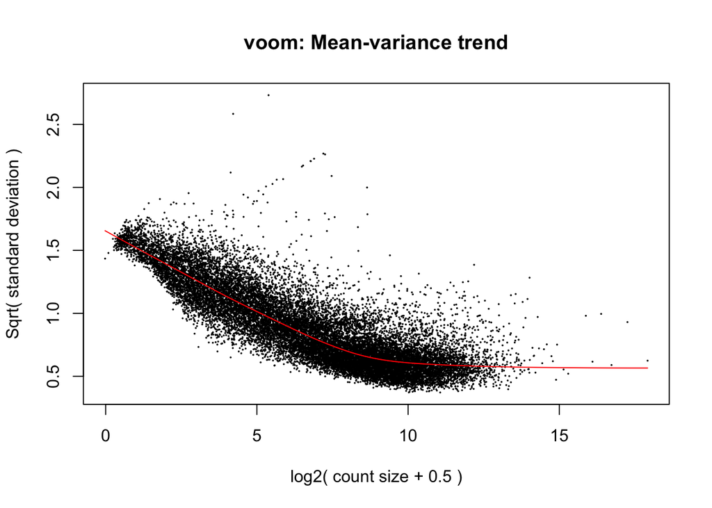

```
## [1] -0.015147
```

```r
DeltaDelta <- DeltaNotProtected <- DeltaProtected <- fit <- design <- xgroup

for(i in names(xgroup)){
  Subject <- factor(xgroup[[i]]$PATID)
  Outcome <- factor(xgroup[[i]]$Outcome, levels = c(1,0), labels = c("NotProtected","Protected"))
  Timepoint <- factor(xgroup[[i]]$Timepoint, levels = c(0,25), labels = c("baseline","postvax"))
  Batch <- factor(xgroup[[i]]$SEQBATCH, levels = c("Aug2019","Nov2019"))
  Sex <- factor(xgroup[[i]]$SEX)
  Site <- factor(xgroup[[i]]$site)
  Pf_VAX1 <- factor(xgroup[[i]]$mal.vax.1)
  MALdVaxTotal <- as.numeric(ifelse(is.na(xgroup[[i]]$mal.dvax.tot), median(xgroup[[i]]$mal.dvax.tot, na.rm = TRUE), xgroup[[i]]$mal.dvax.tot)) #Impute  missing values with median of all samples (there are no missing values in high-dose PfSPZ group)
  MALdVax <- factor(xgroup[[i]]$mal.dvax)
  CSPAb_baseline <- as.numeric(xgroup[[i]]$pfcsp_pre)
  CSPAb_baseline[is.na(CSPAb_baseline)] <- median(CSPAb_baseline, na.rm = TRUE) #Impute 2 missing values with median of all samples
  CSPAb_baseline <- log10(CSPAb_baseline+1) #log transform to make linear
  #Define protective outcome-specific PfSPZ Vaccination effects and append them to the design matrix
  Protected.Postvax <- Outcome == "Protected" & Timepoint=="postvax"
  NotProtected.Postvax <- Outcome =="NotProtected" & Timepoint=="postvax"
  design[[i]] <- model.matrix(~Batch+Sex+Site+CSPAb_baseline+MALdVaxTotal)
  design[[i]] <- cbind(design[[i]], Protected.Postvax, NotProtected.Postvax) #make design matrix according to edgeR 3.5 (p42)
  #https://www.bioconductor.org/packages/release/bioc/vignettes/edgeR/inst/doc/edgeRUsersGuide.pdf
  rownames(design[[i]]) <- xgroup[[i]]$PATID
  print(paste0("running model fit for ", i))
  print(colnames(design[[i]])) #check colnames

  #See 18.1.9 of Limma user guide
  #Use voom() to convert the read counts to log2-cpm, with associated weights, ready for linear modeling

  v <- voom(ygroup[[i]], design[[i]])
  cor <- duplicateCorrelation(v, design[[i]], block = Subject)
  print(cor$consensus)
  v <- voom(ygroup[[i]], design[[i]], plot = TRUE, block = Subject, correlation = cor$consensus)
  cor <- duplicateCorrelation(v, design[[i]], block = Subject)
  print(cor$consensus)

  #fit
  fit <- lmFit(v, design[[i]], block = Subject, correlation = cor$consensus)
  fit <- eBayes(fit)
  DeltaProtected[[i]] <- topTable(fit,n=Inf, coef="Protected.Postvax")
  DeltaNotProtected[[i]] <-  topTable(fit,n=Inf, coef="NotProtected.Postvax")
  fit2 <- contrasts.fit(fit, contrasts = c(rep(0,(ncol(design[[i]])-2)),1,-1))
  fit2 <- eBayes(fit2)
  DeltaDelta[[i]] <- topTable(fit2,n=Inf)
}
```

### Examine top 15 DEGs in 1.8x10^6 PfSPZ dose group

Δ Protected

```r
DeltaProtected$`1.8 x 10^6 PfSPZ`[1:15,c(7,9,2:5,8,10:15)] %>%
  mutate_if(is.numeric, signif,3) %>%
  knitr::kable(., row.names = FALSE)
```

| GeneSymbol | EnsemblID | Chromosome | Start | End | Probe.Strand | descripton_new | logFC | AveExpr | t | P.Value | adj.P.Val | B |
| --- | --- | --- | --- | --- | --- | --- | --- | --- | --- | --- | --- | --- |
| MTMR4 | ENSG00000108389 | 17 | 58489529 | 58517905 | - | myotubularin related protein 4 [Source:HGNC Symbol;Acc:HGNC:7452] | -0.205 | 5.91 | -4.66 | 8.40e-06 | 0.0916 | 3.410 |
| RTF1 | ENSG00000137815 | 15 | 41408408 | 41483563 | + | RTF1 homolog, Paf1/RNA polymerase II complex component [Source:HGNC Symbol;Acc:HGNC:28996] | -0.242 | 5.65 | -4.63 | 9.30e-06 | 0.0916 | 3.320 |
| SLC4A1AP | ENSG00000163798 | 2 | 27663471 | 27694976 | + | solute carrier family 4 member 1 adaptor protein [Source:HGNC Symbol;Acc:HGNC:13813] | -0.239 | 4.82 | -4.53 | 1.40e-05 | 0.0916 | 2.930 |
| ZDHHC14 | ENSG00000175048 | 6 | 157381133 | 157678146 | + | zinc finger DHHC-type palmitoyltransferase 14 [Source:HGNC Symbol;Acc:HGNC:20341] | 0.379 | 4.03 | 4.44 | 2.00e-05 | 0.0930 | 2.570 |
| XRN2 | ENSG00000088930 | 20 | 21303304 | 21389827 | + | 5’-3’ exoribonuclease 2 [Source:HGNC Symbol;Acc:HGNC:12836] | -0.228 | 6.66 | -4.35 | 2.84e-05 | 0.0930 | 2.290 |
| MASP2 | ENSG00000009724 | 1 | 11026523 | 11047233 | - | MBL associated serine protease 2 [Source:HGNC Symbol;Acc:HGNC:6902] | 0.319 | 3.84 | 4.32 | 3.31e-05 | 0.0930 | 2.110 |
| YARS1 | ENSG00000134684 | 1 | 32775237 | 32818153 | - | tyrosyl-tRNA synthetase 1 [Source:HGNC Symbol;Acc:HGNC:12840] | -0.218 | 6.13 | -3.98 | 1.19e-04 | 0.2930 | 0.988 |
| YWHAG | ENSG00000170027 | 7 | 76326794 | 76359031 | - | tyrosine 3-monooxygenase/tryptophan 5-monooxygenase activation protein gamma [Source:HGNC Symbol;Acc:HGNC:12852] | -0.238 | 6.47 | -3.93 | 1.45e-04 | 0.3100 | 0.804 |
| ZRSR2 | ENSG00000169249 | X | 15790472 | 15823260 | + | zinc finger CCCH-type, RNA binding motif and serine/arginine rich 2 [Source:HGNC Symbol;Acc:HGNC:23019] | 0.291 | 3.85 | 3.90 | 1.57e-04 | 0.3100 | 0.756 |
| COPG1 | ENSG00000181789 | 3 | 129249606 | 129277773 | + | COPI coat complex subunit gamma 1 [Source:HGNC Symbol;Acc:HGNC:2236] | -0.291 | 5.90 | -3.81 | 2.18e-04 | 0.3130 | 0.449 |
| SH3KBP1 | ENSG00000147010 | X | 19533975 | 19887601 | - | SH3 domain containing kinase binding protein 1 [Source:HGNC Symbol;Acc:HGNC:13867] | -0.221 | 7.56 | -3.82 | 2.13e-04 | 0.3130 | 0.430 |
| ZBTB39 | ENSG00000166860 | 12 | 56998834 | 57006446 | - | zinc finger and BTB domain containing 39 [Source:HGNC Symbol;Acc:HGNC:29014] | 0.216 | 5.13 | 3.79 | 2.39e-04 | 0.3130 | 0.386 |
| NUDT19 | ENSG00000213965 | 19 | 32691961 | 32713796 | + | nudix hydrolase 19 [Source:HGNC Symbol;Acc:HGNC:32036] | -0.322 | 4.04 | -3.78 | 2.50e-04 | 0.3130 | 0.358 |
| NCL | ENSG00000115053 | 2 | 231453531 | 231483641 | - | nucleolin [Source:HGNC Symbol;Acc:HGNC:7667] | -0.246 | 7.31 | -3.79 | 2.39e-04 | 0.3130 | 0.329 |
| TXNRD1 | ENSG00000198431 | 12 | 104215779 | 104350305 | + | thioredoxin reductase 1 [Source:HGNC Symbol;Acc:HGNC:12437] | -0.231 | 5.96 | -3.77 | 2.55e-04 | 0.3130 | 0.306 |

Δ Not Protected

```r
DeltaNotProtected$`1.8 x 10^6 PfSPZ`[1:15,c(7,9,2:5,8,10:15)] %>%
  mutate_if(is.numeric, signif,3) %>%
  knitr::kable(., row.names = FALSE)
```

| GeneSymbol | EnsemblID | Chromosome | Start | End | Probe.Strand | descripton_new | logFC | AveExpr | t | P.Value | adj.P.Val | B |
| --- | --- | --- | --- | --- | --- | --- | --- | --- | --- | --- | --- | --- |
| TMPO-AS1 | ENSG00000257167 | 12 | 98512973 | 98516422 | - | TMPO antisense RNA 1 [Source:HGNC Symbol;Acc:HGNC:44158] | 0.357 | 5.11 | 4.22 | 4.86e-05 | 0.417 | 1.8100 |
| PPM1N | ENSG00000213889 | 19 | 45488777 | 45502510 | + | protein phosphatase, Mg2+/Mn2+ dependent 1N (putative) [Source:HGNC Symbol;Acc:HGNC:26845] | 0.740 | 2.11 | 4.18 | 5.55e-05 | 0.417 | 1.0700 |
| PSMG3 | ENSG00000157778 | 7 | 1567330 | 1571005 | - | proteasome assembly chaperone 3 [Source:HGNC Symbol;Acc:HGNC:22420] | 0.443 | 2.71 | 3.98 | 1.20e-04 | 0.417 | 0.6860 |
| STK4 | ENSG00000101109 | 20 | 44966474 | 45079959 | + | serine/threonine kinase 4 [Source:HGNC Symbol;Acc:HGNC:11408] | -0.177 | 9.36 | -3.73 | 2.98e-04 | 0.489 | 0.1650 |
| MXRA7 | ENSG00000182534 | 17 | 76672551 | 76711016 | - | matrix remodeling associated 7 [Source:HGNC Symbol;Acc:HGNC:7541] | 0.732 | 3.30 | 3.72 | 3.07e-04 | 0.489 | 0.0804 |
| RP11-536K7.3 | ENSG00000232807 | 10 | 5934270 | 5945900 | - | novel transcript, antisense to FBXO18 | -0.262 | 3.57 | -3.66 | 3.83e-04 | 0.489 | -0.0907 |
| AC007283.5 | ENSG00000234431 | 2 | 201166965 | 201167546 | + | novel transcript | -0.405 | 3.94 | -3.63 | 4.23e-04 | 0.489 | -0.1360 |
| ALDH6A1 | ENSG00000119711 | 14 | 74056850 | 74084493 | - | aldehyde dehydrogenase 6 family member A1 [Source:HGNC Symbol;Acc:HGNC:7179] | -0.360 | 5.02 | -3.57 | 5.24e-04 | 0.542 | -0.2790 |
| BATF | ENSG00000156127 | 14 | 75522425 | 75547015 | + | basic leucine zipper ATF-like transcription factor [Source:HGNC Symbol;Acc:HGNC:958] | 0.730 | 1.97 | 3.70 | 3.28e-04 | 0.489 | -0.3250 |
| C1QBP | ENSG00000108561 | 17 | 5432777 | 5448830 | - | complement C1q binding protein [Source:HGNC Symbol;Acc:HGNC:1243] | 0.304 | 6.01 | 3.50 | 6.59e-04 | 0.567 | -0.5040 |
| CKS2 | ENSG00000123975 | 9 | 89311198 | 89316703 | + | CDC28 protein kinase regulatory subunit 2 [Source:HGNC Symbol;Acc:HGNC:2000] | 0.690 | 1.86 | 3.63 | 4.21e-04 | 0.489 | -0.5180 |
| RNF38 | ENSG00000137075 | 9 | 36336396 | 36487548 | - | ring finger protein 38 [Source:HGNC Symbol;Acc:HGNC:18052] | -0.199 | 7.32 | -3.48 | 6.96e-04 | 0.567 | -0.5730 |
| H4C11 | ENSG00000197238 | 6 | 27824108 | 27824480 | + | H4 clustered histone 11 [Source:HGNC Symbol;Acc:HGNC:4785] | 0.571 | 2.08 | 3.59 | 4.83e-04 | 0.528 | -0.5830 |
| ARPC5L | ENSG00000136950 | 9 | 124862130 | 124877733 | + | actin related protein 2/3 complex subunit 5 like [Source:HGNC Symbol;Acc:HGNC:23366] | 0.275 | 4.20 | 3.46 | 7.51e-04 | 0.567 | -0.5900 |
| RP3-461F17.3 | ENSG00000268439 | 12 | 6970921 | 6997428 | + | NA | 0.272 | 3.78 | 3.45 | 7.65e-04 | 0.567 | -0.6220 |

Δ Protected vs. Δ Not Protected

```r
DeltaDelta$`1.8 x 10^6 PfSPZ`[1:15,c(7,9,2:5,8,10:15)] %>%
  mutate_if(is.numeric, signif,3) %>%
  knitr::kable(., row.names = FALSE)
```

| GeneSymbol | EnsemblID | Chromosome | Start | End | Probe.Strand | descripton_new | logFC | AveExpr | t | P.Value | adj.P.Val | B |
| --- | --- | --- | --- | --- | --- | --- | --- | --- | --- | --- | --- | --- |
| RNF144A | ENSG00000151692 | 2 | 6917392 | 7068286 | + | ring finger protein 144A [Source:HGNC Symbol;Acc:HGNC:20457] | 0.329 | 6.29 | 3.67 | 0.000366 | 0.948 | -1.51 |
| MED28 | ENSG00000118579 | 4 | 17614631 | 17634105 | + | mediator complex subunit 28 [Source:HGNC Symbol;Acc:HGNC:24628] | 0.179 | 7.74 | 3.43 | 0.000837 | 0.948 | -1.76 |
| RP11-440L14.1 | ENSG00000249592 | 4 | 762387 | 781849 | - | novel transcript, antisense to PCGF3 | 0.271 | 4.53 | 3.75 | 0.000271 | 0.948 | -2.01 |
| RFX5 | ENSG00000143390 | 1 | 151340640 | 151347357 | - | regulatory factor X5 [Source:HGNC Symbol;Acc:HGNC:9986] | -0.158 | 6.22 | -3.28 | 0.001360 | 0.948 | -2.17 |
| KAT7 | ENSG00000136504 | 17 | 49788555 | 49835030 | + | lysine acetyltransferase 7 [Source:HGNC Symbol;Acc:HGNC:17016] | 0.143 | 7.25 | 3.19 | 0.001830 | 0.948 | -2.21 |
| ANXA4 | ENSG00000196975 | 2 | 69644425 | 69826464 | + | annexin A4 [Source:HGNC Symbol;Acc:HGNC:542] | -0.345 | 5.70 | -3.31 | 0.001250 | 0.948 | -2.21 |
| LDHA | ENSG00000134333 | 11 | 18394388 | 18408425 | + | lactate dehydrogenase A [Source:HGNC Symbol;Acc:HGNC:6535] | -0.245 | 7.21 | -3.04 | 0.002920 | 0.948 | -2.46 |
| VDAC1 | ENSG00000213585 | 5 | 133971915 | 134005133 | - | voltage dependent anion channel 1 [Source:HGNC Symbol;Acc:HGNC:12669] | -0.253 | 5.75 | -3.14 | 0.002130 | 0.948 | -2.46 |
| PSMC2 | ENSG00000161057 | 7 | 103344254 | 103369395 | + | proteasome 26S subunit, ATPase 2 [Source:HGNC Symbol;Acc:HGNC:9548] | -0.259 | 5.40 | -3.19 | 0.001840 | 0.948 | -2.47 |
| C1QBP | ENSG00000108561 | 17 | 5432777 | 5448830 | - | complement C1q binding protein [Source:HGNC Symbol;Acc:HGNC:1243] | -0.300 | 6.01 | -3.10 | 0.002440 | 0.948 | -2.48 |
| MAML2 | ENSG00000184384 | 11 | 95976598 | 96343180 | - | mastermind like transcriptional coactivator 2 [Source:HGNC Symbol;Acc:HGNC:16259] | 0.242 | 7.32 | 3.00 | 0.003270 | 0.948 | -2.51 |
| H2AZ1 | ENSG00000164032 | 4 | 99948086 | 99950388 | - | H2A.Z variant histone 1 [Source:HGNC Symbol;Acc:HGNC:4741] | -0.340 | 6.02 | -3.08 | 0.002610 | 0.948 | -2.51 |
| SLBP | ENSG00000163950 | 4 | 1692800 | 1712555 | - | stem-loop binding protein [Source:HGNC Symbol;Acc:HGNC:10904] | -0.268 | 5.14 | -3.20 | 0.001770 | 0.948 | -2.52 |
| SEPTIN2 | ENSG00000168385 | 2 | 241315100 | 241354027 | + | septin 2 [Source:HGNC Symbol;Acc:HGNC:7729] | -0.183 | 7.37 | -2.99 | 0.003390 | 0.948 | -2.53 |
| TGFBR2 | ENSG00000163513 | 3 | 30606502 | 30694142 | + | transforming growth factor beta receptor 2 [Source:HGNC Symbol;Acc:HGNC:11773] | 0.168 | 9.21 | 2.94 | 0.003990 | 0.948 | -2.54 |

### Apply GSEA

Rank genes by -log10(P.Value)*sign(logFC). Run fgsea from fgsea package using NamedGeneRankList2GseaTable helper function.

```r
set.seed(23)
#restructure dataframes
degtabs <- ygroup
for(i in names(ygroup)){
    degtabs[[i]] <- setNames(as.list(c(1:3)), c("DeltaDelta", "DeltaP", "DeltaNP"))
    degtabs[[i]]$DeltaDelta <- DeltaDelta[[i]]
    degtabs[[i]]$DeltaP <- DeltaProtected[[i]]
    degtabs[[i]]$DeltaNP <- DeltaNotProtected[[i]]
}
ranks <- degtabs
for(i in names(degtabs)){
  for(j in names(degtabs[[i]])){
    ranks[[i]][[j]] <-  degtabs[[i]][[j]] %>%
      mutate(rankmetric = -log10(.$P.Value)*sign(.$logFC)) %>%
      dplyr::select(GeneSymbol,rankmetric) %>%
      na.omit() %>%
      distinct() %>%
      group_by(GeneSymbol) %>%
      summarize(rankmetric = mean(rankmetric)) %>%
      arrange(desc(rankmetric))
  }
}
#Run fgsea from fgsea package using NamedGeneRankList2GseaTable helper function
devtools::source_url("https://github.com/TranLab/ModuleLists/blob/main/NamedGeneRankList2GseaTable.R?raw=TRUE")
GSEAtab <- ranks
for(i in names(ranks)){
  for(j in names(ranks[[i]])){
    print(paste0("starting ", j, " in ", i))
    GSEAtab[[i]][[j]] <- NamedGeneRankList2GseaTable(rankedgenes = deframe(ranks[[i]][[j]]),
                                                     geneset = "bloodmodules",
                                                     output_directory = tempdir(),
                                                     filename_prefix = "GSEA",
                                                     sampleSize = 101,
                                                     minSize = 20,
                                                     maxSize = Inf,
                                                     scoreType = "std") %>%
      as_tibble() %>%
      arrange(desc(NES)) %>%
      dplyr::select(module_type, pathway, ES, NES, size, leadingEdge, pval, padj) %>%
      mutate(leadingEdge = gsub("^c\\(|\\)$", "", leadingEdge)) %>%
      mutate(leadingEdge = gsub('"', "", leadingEdge)) %>%
      arrange(padj)
    #closeAllConnections() #this line prevents using up all url connections
    }
}
```

```
## [1] "starting DeltaDelta in 1.8 x 10^6 PfSPZ"
## [1] "Running fgsea for MonacoModules signatures"
## [1] "Running fgsea for highBTMs signatures"
## [1] "Running fgsea for lowBTMs signatures"
## [1] "Running fgsea for BloodGen3Module signatures"
## [1] "starting DeltaP in 1.8 x 10^6 PfSPZ"
## [1] "Running fgsea for MonacoModules signatures"
## [1] "Running fgsea for highBTMs signatures"
## [1] "Running fgsea for lowBTMs signatures"
## [1] "Running fgsea for BloodGen3Module signatures"
## [1] "starting DeltaNP in 1.8 x 10^6 PfSPZ"
## [1] "Running fgsea for MonacoModules signatures"
## [1] "Running fgsea for highBTMs signatures"
## [1] "Running fgsea for lowBTMs signatures"
## [1] "Running fgsea for BloodGen3Module signatures"
```

### Visualize GSEA data as bubble plot

Filter based on padj < 0.20.

```r
plotDat <- GSEAtab$`1.8 x 10^6 PfSPZ` %>%
  bind_rows(., .id = "comparison") %>%
  mutate(comparison = factor(comparison, levels = c("DeltaP", "DeltaNP", "DeltaDelta"), labels = c("DeltaP", "DeltaNP", "DeltaDelta"))) %>%
  filter(padj < 0.20) %>%
  filter(module_type %in% c("highBTMs", "lowBTMs", "MonacoModules", "BloodGen3Module"))  %>%
  filter(!grepl("TBA", pathway)) %>%
  dplyr::select(comparison, module_type, pathway, leadingEdge, size, NES, padj) %>%
  mutate(neglogpadj = -log10(padj)) %>%
  mutate(pathway = gsub("gd", "γδ", pathway)) %>%
  mutate(pathway = gsub("Vd2", "Vδ2", pathway)) %>%
  mutate(pathway = gsub("Vg", "Vγ", pathway)) %>%
  mutate(pathway = gsub("HALLMARK_", "", pathway)) %>%
  mutate(pathway = gsub("_", " ", pathway)) %>%
  mutate(pathway = sub(".*?\\_", "", pathway)) %>%
  group_by(module_type) %>%
  mutate(pathway = fct_reorder(pathway, NES, .desc = TRUE)) %>%
  ungroup() %>%
  filter(!grepl("TBD", pathway)) %>%
  mutate(module_type = factor(module_type, levels = c("highBTMs", "MonacoModules", "lowBTMs", "BloodGen3Module"))) %>%
  arrange(desc(neglogpadj)) %>%
  droplevels()

foodat <- plotDat %>%
  filter(comparison == "DeltaNP")
#plotting options
basetextsize <- 8
myfont <- "sans"
bubble_max_size <- 6

MyPlot <- plotDat %>%
  filter(module_type %in% c("highBTMs", "MonacoModules"))  %>%
  ggplot(., aes(x = comparison, y = pathway)) +
  geom_point(aes(size=neglogpadj, fill = NES), alpha = 0.65, shape=21, stroke = 0.25) +
  scale_size_area(name = expression(-log[10]~adj.~p~value), max_size = bubble_max_size) +
      scale_fill_gradient2(low = "blue",
                           mid = "white",
                           high = "red") +
  hrbrthemes::theme_ipsum_es(base_family = myfont, base_size = basetextsize) +
  theme(axis.title.x = element_blank(),
        axis.title.y = element_blank(),
        strip.background = element_blank(),
        legend.position = "bottom",
        axis.text.x = element_text(angle = 90, vjust = 0.5, hjust=1)) +
  facet_wrap(~module_type, scales = "free_y", ncol = 2)
```

### Plot GSEA bubbleplots (Figures 4G of pre-print)

Red: enriched in protected/uninfected through 3 months post-vax surveillance Blue: enriched in not protected/infected through 3 months post-vax surveillance

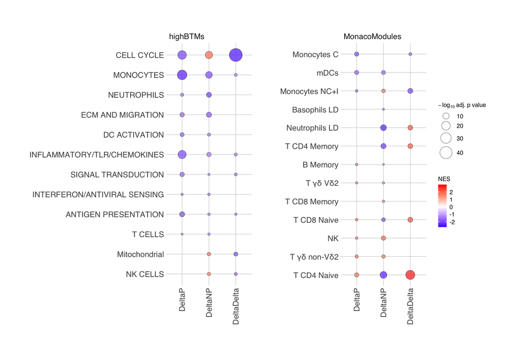

```r
addSmallLegend <- function(myPlot, pointSize = 4, textSize = 6, spaceLegend = 0.6) {
    myPlot +
        guides(shape = guide_legend(override.aes = list(size = pointSize)),
               color = guide_legend(override.aes = list(size = pointSize))) +
        theme(strip.text = element_text(size=8),
              legend.direction = "vertical",
              legend.position = "right",
              legend.title = element_text(size = textSize),
              legend.text  = element_text(size = textSize),
              legend.key.size = unit(spaceLegend, "lines"))
}
print(addSmallLegend(MyPlot))
```

### Gene-level analysis

1. Identify genes that were differentially induced in uninfected and infected children receiving 1.8x10^6 PfSPZ Vaccine
2. Merge ΔP vs ΔNP, ΔP, and ΔNP tables.
3. Criteria: ΔP vs ΔNP P val < 0.005 ΔP logFC > 0 and ΔP P val < 0.05 ΔNP logFC < 0 and ΔNP P val < 0.10

```r
AllDegs1 <- bind_rows(DeltaDelta, .id = "Treatment") %>%
  mutate(Comparison = "DeltaDelta")
AllDegs2 <- bind_rows(DeltaProtected, .id = "Treatment") %>%
  mutate(Comparison = "DeltaProtected")
AllDegs3 <- bind_rows(DeltaNotProtected, .id = "Treatment") %>%
  mutate(Comparison = "DeltaNotProtected")
AllDegs <- bind_rows(AllDegs1, AllDegs2, AllDegs3) %>%
  dplyr::select(Treatment, Comparison, EnsemblID, GeneSymbol, descripton_new, logFC, AveExpr, "t", P.Value, adj.P.Val) %>%
  dplyr::rename(PValue = P.Value) %>%
  dplyr::rename(FDR = adj.P.Val) %>%
  dplyr::rename(Description = "descripton_new")

gois <- AllDegs %>%
  filter(Treatment == "1.8 x 10^6 PfSPZ") %>%
  droplevels() %>%
  dplyr::select(Treatment, Comparison, EnsemblID, GeneSymbol, Description, logFC, PValue, FDR) %>%
  pivot_wider(., names_from = Comparison, names_glue = "{Comparison}_{.value}", values_from = c(logFC, PValue, FDR)) %>%
  filter(DeltaDelta_PValue < 0.005 &
           (DeltaProtected_logFC > 0 & DeltaProtected_PValue < 0.05) &
           (DeltaNotProtected_logFC < 0 & DeltaNotProtected_PValue < 0.10)) %>%
  arrange(DeltaDelta_PValue)

gois_ms <- gois %>%
  dplyr::select(GeneSymbol, DeltaDelta_logFC, DeltaDelta_PValue, DeltaProtected_logFC, DeltaProtected_PValue, DeltaNotProtected_logFC, DeltaNotProtected_PValue)
```

### Figure 4H in pre-print

```r
gois_ms %>%
  mutate_if(is.numeric, signif,3) %>%
  knitr::kable()
```

| GeneSymbol | DeltaDelta_logFC | DeltaDelta_PValue | DeltaProtected_logFC | DeltaProtected_PValue | DeltaNotProtected_logFC | DeltaNotProtected_PValue |
| --- | --- | --- | --- | --- | --- | --- |
| RP11-440L14.1 | 0.271 | 0.000271 | 0.1320 | 0.0186 | -0.1400 | 0.0367 |
| MED28 | 0.179 | 0.000837 | 0.0968 | 0.0182 | -0.0818 | 0.0854 |
| FSTL4 | 2.090 | 0.001360 | 0.8720 | 0.0430 | -1.2200 | 0.0511 |
| KAT7 | 0.143 | 0.001830 | 0.0701 | 0.0462 | -0.0729 | 0.0750 |
| TMEM220-AS1 | 1.450 | 0.002280 | 0.7150 | 0.0359 | -0.7400 | 0.0946 |

### Reshape and merge for survival analysis

```r
library(gtools)
#from google drive
temp <- tempfile(fileext = ".rds")
dl <- drive_download(
  as_id("17xx0YaggLiyWdJc9rqA1nkPSE7dj05p0"), path = temp, overwrite = TRUE)
cpm_delta <- readRDS(file = dl$local_path)
cpm_delta <- cpm_delta[fData(cpm_delta)$GeneSymbol %in% gois_ms$GeneSymbol, ]
cpm_delta <- cpm_delta[,cpm_delta$treat != "Placebo"]
pData(cpm_delta) <- droplevels(pData(cpm_delta))
survdat <- Biobase::exprs(cpm_delta) %>%
  as.data.frame() %>%
  rownames_to_column(var = "EnsemblID") %>%
  left_join(., fData(cpm_delta) %>%
              dplyr::select(EnsemblID, GeneSymbol),
            by = "EnsemblID") %>%
  dplyr::select(-c(EnsemblID)) %>%
  dplyr::select(GeneSymbol, everything()) %>%
  pivot_longer(2:ncol(.), names_to = "PATID", values_to = "expression") %>%
  group_by(GeneSymbol) %>%
  mutate(exprs_up_down = factor(ifelse(expression>log2(1), "induced", "not induced"), levels = c("not induced", "induced"))) %>%
  mutate(exprs_terciles = factor(quantcut(expression, q=3, na.rm=TRUE), labels = c("bottom_tercile", "middle_tercile", "top_tercile"))) %>%
  mutate(exprs_median = factor(quantcut(expression, q=2, na.rm=TRUE), labels = c("bottom", "top"))) %>%
  left_join(., fData(cpm_delta) %>%
              dplyr::select(c(GeneSymbol, description)), by = "GeneSymbol") %>%
  left_join(., pData(cpm_delta)%>%
              dplyr::select(c(PATID, Timepoint, treat, site, SEX, pfcsp_pre, age.vax1, mal.vax.1, mal.dvax, mal.dvax.tot, contains("atp"))), by = "PATID") %>%
  droplevels()
survdat$tte.mal.atp.6 <- survdat$tte.mal.atp.6+1
survdat[is.na(survdat$pfcsp_pre),]$pfcsp_pre <- median(survdat$pfcsp_pre, na.rm = TRUE) #Impute 2 missing values with median of all samples
```

### Kaplan-Meier plots

FSTL4 is in Figure 4I of preprint

```r
library(survival)
library(survminer)
myFollowup <- 6 #3 or 6
N <- length(unique(survdat$PATID))
survdat.filtered <- fit <- mySurvPlot <- c()
for(i in gois_ms$GeneSymbol){
  survdat.filtered[[i]] <- survdat %>%
    filter(GeneSymbol == i)
  fit[[i]] <- survfit(Surv(tte.mal.atp.6, mal.atp.6) ~ exprs_up_down, data= survdat.filtered[[i]])
  mySurvPlot[[i]] <- ggsurvplot(fit[[i]], risk.table = TRUE, pval = TRUE,
                                break.time.by = 30, title = unique(survdat.filtered[[i]]$GeneSymbol),
                                xlab = "Days since vaccination",
                                ylab = "% free of parasitemia",
                                censor = TRUE,
                                palette = "lancet",
                                conf.int = TRUE,
                                conf.int.alpha = 0.1,
                                font.family = "Arial")
}
```

### Fig 4I of preprint

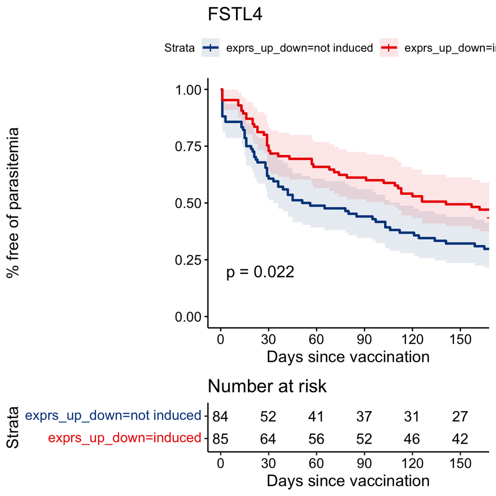

### Cox Regression

```r
cox.res <- c()
for(i in names(survdat.filtered)){
  survdat.cp <- survdat.filtered[[i]]
  survdat.cp$tte.mal.atp.6 <- survdat.cp$tte.mal.atp.6 + 1 #add one day to each value given zero values
  survdat.cp$start      <-      0
  survdat.cp$stop       <-      survdat.cp$tte.mal.atp.6
  subj.pcrp <- rep(survdat.cp$start, as.vector(table(survdat.cp$PATID)))
  survdat.cp$start1 <- survdat.cp$start-subj.pcrp
  survdat.cp$stop1 <- survdat.cp$stop-subj.pcrp
  survdat.cp <- survdat.cp %>%
    droplevels()
  fit <- coxph(Surv(start1, stop1, mal.atp.6) ~ exprs_up_down + factor(SEX) + factor(site) + log10(pfcsp_pre+1) + mal.dvax.tot + factor(treat), data = survdat.cp)
  #vfit <- cox.zph(fit)
  #par(mfrow=c(3,2))
  #plot(vfit)
  #cox.zph(fit)
  cox.res[[i]] <- as.data.frame(cbind(fit$n, fit$nevent, summary(fit)$conf.int[,c(1,3:4)], summary(fit)$coefficient[,5]))
  colnames(cox.res[[i]]) <- c("n","number of events","HR", "LCI", "UCI", "P value")
  cox.res[[i]] <- cox.res[[i]] %>%
    as.matrix() %>%
    signif(., digits = 3) %>%
    as.data.frame()
  cox.res[[i]]$Gene <- i
  rownames(cox.res[[i]]) <- c("upregulated post-vax (ref:downregulated post-vax)",
                              "gender (ref:female)",
                              "Wagai (ref:Siaya)",
                              "CSP-specific IgG baseline",
                              "number of Pf infections during vaccination period",
                              "9.0x10^5 PfSPZ (ref:4.5x10^5 PfSPZ)",
                              "1.8x10^6 PfSPZ (ref:4.5x10^5 PfSPZ)")
  cox.res[[i]] <- cox.res[[i]] %>%
    rownames_to_column(var = "Covariate") %>%
    dplyr::select(Gene, everything())
  }
  cox.res.bound <- bind_rows(cox.res, .id = "Gene") %>%
    mutate(Significant = ifelse(`P value`<0.001, "***",
                              ifelse(`P value`<0.01, "**",
                                     ifelse(`P value`<0.05, "*", ""))))

cox.res.bound %>%
  dplyr::filter(`P value` < 0.05 & Covariate == "upregulated post-vax (ref:downregulated post-vax)") %>%
  arrange(HR,`P value`)
```

```
##    Gene                                         Covariate   n number of events
## 1 FSTL4 upregulated post-vax (ref:downregulated post-vax) 169              107
##      HR   LCI   UCI P value Significant
## 1 0.643 0.433 0.954  0.0282           *
```

### Table S4 of preprint

Only display FSTL4 here.

```r
cox.res.bound %>%
  filter(Gene == "FSTL4") %>%
  knitr::kable()
```

| Gene | Covariate | n | number of events | HR | LCI | UCI | P value | Significant |
| --- | --- | --- | --- | --- | --- | --- | --- | --- |
| FSTL4 | upregulated post-vax (ref:downregulated post-vax) | 169 | 107 | 0.643 | 0.433 | 0.954 | 0.02820 | * |
| FSTL4 | gender (ref:female) | 169 | 107 | 0.920 | 0.618 | 1.370 | 0.67900 |  |
| FSTL4 | Wagai (ref:Siaya) | 169 | 107 | 0.629 | 0.421 | 0.939 | 0.02340 | * |
| FSTL4 | CSP-specific IgG baseline | 169 | 107 | 1.000 | 0.795 | 1.260 | 0.99900 |  |
| FSTL4 | number of Pf infections during vaccination period | 169 | 107 | 1.250 | 1.070 | 1.460 | 0.00465 | ** |
| FSTL4 | 9.0x10^5 PfSPZ (ref:4.5x10^5 PfSPZ) | 169 | 107 | 1.100 | 0.693 | 1.760 | 0.67700 |  |
| FSTL4 | 1.8x10^6 PfSPZ (ref:4.5x10^5 PfSPZ) | 169 | 107 | 0.899 | 0.551 | 1.470 | 0.66900 |  |